# Oil and asset classes implied volatilities: Investment strategies and hedging effectiveness

Antonakakis, Cunado, Filis, Gabauer, & Gracia (2020)

Load data and extract useful information:

```r
data("g2020")
k = ncol(g2020)
NAMES = colnames(g2020)
```

First, it is shown how the ‘optimal’ univariate GARCH model is selected for EUR. The model with the lowest value is chosen:

```r
# Find the best univariate model for EUR
gs = GARCHselection(g2020$EUR,
  distributions=c("norm","std"),
  models=c("sGARCH", "eGARCH")
)
```

```
## A dynamic version of the optimal univariate GARCH selection procedure is implemented according to:
##  Antonakakis, N., Chatziantoniou, I., & Gabauer, D. (2021). The impact of Euro through time: Exchange rate dynamics under different regimes. International Journal of Finance & Economics, 26(1), 1375-1408.
```

```
## -sGARCH
```

```
## --norm
```

```
## --std
```

```
## -eGARCH
```

```
## --norm
```

```
## --std
```

```r
kable(gs$GARCH_IC)
```

|  | sGARCH | eGARCH |
| --- | --- | --- |
| norm | 207205.4 | 307192.6 |
| std | 107120.6 | 207121.5 |

```r
kable(gs$best_table)
```

| x |
| --- |
| 107120.6 |

|  | SignBias | WARCH(20) | VaR | CVaR | VaR Dur. |
| --- | --- | --- | --- | --- | --- |
| statistics | 0.6321013 | 549.5404 | 2.2520225 | -906.7897 | 1.1142857 |
| pvalues | 0.5273552 | 0.0000 | 0.1334399 | 0.9110 | 0.2314699 |

Find the best univariate models for all time series. As the DCC-GARCH is often a 2-step estimation model where in the first step all univariate GARCH models are estimated and in a second step the DCC-GARCH parameters, optimizing the univariate GARCH models is a straightforward choice:

```r
ds = DCCGARCHselection(
  g2020,
  distributions=c("std", "ged"),
  models=c("sGARCH", "eGARCH")
)
```

[1] “EUR”

```
## A dynamic version of the optimal univariate GARCH selection procedure is implemented according to:
##  Antonakakis, N., Chatziantoniou, I., & Gabauer, D. (2021). The impact of Euro through time: Exchange rate dynamics under different regimes. International Journal of Finance & Economics, 26(1), 1375-1408.
```

```
## -sGARCH
```

```
## --std
```

```
## --ged
```

```
## -eGARCH
```

```
## --std
```

```
## --ged
```

[1] “GBP”

```
## A dynamic version of the optimal univariate GARCH selection procedure is implemented according to:
##  Antonakakis, N., Chatziantoniou, I., & Gabauer, D. (2021). The impact of Euro through time: Exchange rate dynamics under different regimes. International Journal of Finance & Economics, 26(1), 1375-1408.
```

```
## -sGARCH
```

```
## --std
```

```
## --ged
```

```
## -eGARCH
```

```
## --std
```

```
## --ged
```

[1] “CHF”

```
## A dynamic version of the optimal univariate GARCH selection procedure is implemented according to:
##  Antonakakis, N., Chatziantoniou, I., & Gabauer, D. (2021). The impact of Euro through time: Exchange rate dynamics under different regimes. International Journal of Finance & Economics, 26(1), 1375-1408.
```

```
## -sGARCH
```

```
## --std
```

```
## --ged
```

```
## -eGARCH
```

```
## --std
```

```
## --ged
```

[1] “JPY”

```
## A dynamic version of the optimal univariate GARCH selection procedure is implemented according to:
##  Antonakakis, N., Chatziantoniou, I., & Gabauer, D. (2021). The impact of Euro through time: Exchange rate dynamics under different regimes. International Journal of Finance & Economics, 26(1), 1375-1408.
```

```
## -sGARCH
```

```
## --std
```

```
## --ged
```

```
## -eGARCH
```

```
## --std
```

```
## --ged
```

```r
mspec = cgarchspec(multispec(ds), distribution.model=list(copula="mvt",
                   method="Kendall", time.varying=TRUE))
fit = cgarchfit(mspec, g2020)
H = rcov(fit)
R = rcor(fit)
```

First, we calculate the hedge ratios based upon the conditional variance-covariance matrix of the DCC-GARCH model:

```r
hr = HedgeRatio(g2020, H)
```

```
## Hedge ratios are implemented according to:
##  Kroner, K. F., & Sultan, J. (1993). Time-varying distributions and dynamic hedging with foreign currency futures. Journal of Financial and Quantitative Analysis, 28(4), 535-551.
##
##           Hedging effectiveness is calculated according to:
##  Ederington, L. H. (1979). The hedging performance of the new futures markets. The Journal of Finance, 34(1), 157-170.
##
##           Statistics of the hedging effectiveness measure are implemented according to:
##  Antonakakis, N., Cunado, J., Filis, G., Gabauer, D., & de Gracia, F. P. (2020). Oil and asset classes implied volatilities: Investment strategies and hedging effectiveness. Energy Economics, 91, 104762.
```

```r
kable(hr$TABLE)
```

|  | Mean | Std.Dev. | 5% | 95% | HE | p-value |
| --- | --- | --- | --- | --- | --- | --- |
| EUR/GBP | 0.69 | 0.20 | 0.36 | 1.02 | 0.44 | 0.00 |
| EUR/CHF | 0.79 | 0.17 | 0.48 | 1.00 | 0.56 | 0.00 |
| EUR/JPY | 0.35 | 0.27 | -0.17 | 0.76 | 0.16 | 0.00 |
| GBP/EUR | 0.63 | 0.19 | 0.37 | 0.91 | 0.43 | 0.00 |
| GBP/CHF | 0.51 | 0.19 | 0.20 | 0.77 | 0.26 | 0.00 |
| GBP/JPY | 0.21 | 0.26 | -0.20 | 0.62 | 0.09 | 0.00 |
| CHF/EUR | 0.93 | 0.21 | 0.55 | 1.20 | 0.60 | 0.00 |
| CHF/GBP | 0.66 | 0.27 | 0.27 | 1.11 | 0.27 | 0.00 |
| CHF/JPY | 0.49 | 0.25 | -0.03 | 0.84 | 0.20 | 0.00 |
| JPY/EUR | 0.40 | 0.31 | -0.16 | 0.83 | 0.16 | 0.00 |
| JPY/GBP | 0.28 | 0.31 | -0.21 | 0.79 | 0.10 | 0.00 |
| JPY/CHF | 0.47 | 0.26 | -0.02 | 0.83 | 0.17 | 0.00 |

Second, we compute the time-varying bivariate portfolio weights

```r
bp = BivariatePortfolio(g2020, H)
```

```
## The optimal bivariate portfolios are computed according to:
##  Kroner, K. F., & Ng, V. K. (1998). Modeling asymmetric comovements of asset returns. The Review of Financial Studies, 11(4), 817-844.
##
##           Hedging effectiveness is calculated according to:
##  Ederington, L. H. (1979). The hedging performance of the new futures markets. The Journal of Finance, 34(1), 157-170.
##
##           Statistics of the hedging effectiveness measure are implemented according to:
##  Antonakakis, N., Cunado, J., Filis, G., Gabauer, D., & de Gracia, F. P. (2020). Oil and asset classes implied volatilities: Investment strategies and hedging effectiveness. Energy Economics, 91, 104762.
```

```r
kable(bp$TABLE)
```

|  | Mean | Std.Dev. | 5% | 95% | HE | p-value |
| --- | --- | --- | --- | --- | --- | --- |
| EUR/GBP | 0.43 | 0.24 | 0.00 | 0.83 | 0.22 | 0.00 |
| EUR/CHF | 0.71 | 0.33 | 0.00 | 1.00 | -0.04 | 0.00 |
| EUR/JPY | 0.55 | 0.20 | 0.19 | 0.86 | 0.34 | 0.00 |
| GBP/EUR | 0.57 | 0.24 | 0.17 | 1.00 | 0.22 | 0.00 |
| GBP/CHF | 0.67 | 0.24 | 0.25 | 1.00 | 0.23 | 0.00 |
| GBP/JPY | 0.58 | 0.15 | 0.34 | 0.85 | 0.42 | 0.00 |
| CHF/EUR | 0.29 | 0.33 | 0.00 | 1.00 | 0.20 | 0.22 |
| CHF/GBP | 0.33 | 0.24 | 0.00 | 0.75 | 0.41 | 0.00 |
| CHF/JPY | 0.49 | 0.21 | 0.12 | 0.83 | 0.34 | 0.00 |
| JPY/EUR | 0.45 | 0.20 | 0.14 | 0.81 | 0.40 | 0.00 |
| JPY/GBP | 0.42 | 0.15 | 0.15 | 0.66 | 0.48 | 0.00 |
| JPY/CHF | 0.51 | 0.21 | 0.17 | 0.88 | 0.22 | 0.00 |

Third, we calculate the time-varying minimum variance and minimum correlation portfolios, respectively.

```r
mvp = MinimumConnectednessPortfolio(g2020, H)
```

```
## The minimum connectedness portfolio is implemented according to:
##  Broadstock, D. C., Chatziantoniou, I., & Gabauer, D. (2022). Minimum connectedness portfolios and the market for green bonds: Advocating socially responsible investment (SRI) activity. In Applications in Energy Finance (pp. 217-253). Palgrave Macmillan, Cham.
##
##           Hedging effectiveness is calculated according to:
##  Ederington, L. H. (1979). The hedging performance of the new futures markets. The Journal of Finance, 34(1), 157-170.
##
##           Statistics of the hedging effectiveness measure are implemented according to:
##  Antonakakis, N., Cunado, J., Filis, G., Gabauer, D., & de Gracia, F. P. (2020). Oil and asset classes implied volatilities: Investment strategies and hedging effectiveness. Energy Economics, 91, 104762.
```

```r
kable(mvp$TABLE)
```

|  | Mean | Std.Dev. | 5% | 95% | HE | p-value |
| --- | --- | --- | --- | --- | --- | --- |
| EUR | 0.30 | 0.24 | 0.00 | 0.65 | 0.40 | 0.00 |
| GBP | 0.33 | 0.16 | 0.11 | 0.63 | 0.40 | 0.00 |
| CHF | 0.07 | 0.14 | 0.00 | 0.39 | 0.54 | 0.00 |
| JPY | 0.30 | 0.15 | 0.08 | 0.56 | 0.46 | 0.00 |

```r
mcp = MinimumConnectednessPortfolio(g2020, R)
```

```
## The minimum connectedness portfolio is implemented according to:
##  Broadstock, D. C., Chatziantoniou, I., & Gabauer, D. (2022). Minimum connectedness portfolios and the market for green bonds: Advocating socially responsible investment (SRI) activity. In Applications in Energy Finance (pp. 217-253). Palgrave Macmillan, Cham.
##
##           Hedging effectiveness is calculated according to:
##  Ederington, L. H. (1979). The hedging performance of the new futures markets. The Journal of Finance, 34(1), 157-170.
##
##           Statistics of the hedging effectiveness measure are implemented according to:
##  Antonakakis, N., Cunado, J., Filis, G., Gabauer, D., & de Gracia, F. P. (2020). Oil and asset classes implied volatilities: Investment strategies and hedging effectiveness. Energy Economics, 91, 104762.
```

```r
kable(mcp$TABLE)
```

|  | Mean | Std.Dev. | 5% | 95% | HE | p-value |
| --- | --- | --- | --- | --- | --- | --- |
| EUR | 0.19 | 0.14 | 0.00 | 0.42 | 0.39 | 0.00 |
| GBP | 0.32 | 0.08 | 0.18 | 0.44 | 0.39 | 0.00 |
| CHF | 0.09 | 0.12 | 0.00 | 0.34 | 0.53 | 0.00 |
| JPY | 0.40 | 0.06 | 0.29 | 0.47 | 0.45 | 0.00 |

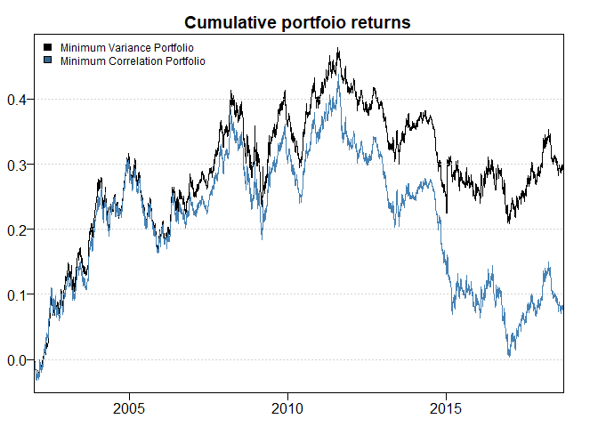

```r
date = index(g2020)
par(mfrow=c(1,1), oma=c(0,0,0,0)+0.5, mar=c(1,1,1,1)+0.5, mgp=c(1,0.4,0))
plot(date, mvp$cumulative_portfolio_return, type="l", las=1, xaxs="i" ,xlab="", ylab="", main="Cumulative portfoio returns", tck=-0.02)
grid(NA, NULL)
lines(date, mcp$cumulative_portfolio_return, col="steelblue")
legend("topleft", c("Minimum Variance Portfolio", "Minimum Correlation Portfolio"), fill=c("black","steelblue4"), bty="n", cex=0.75)
box()
```

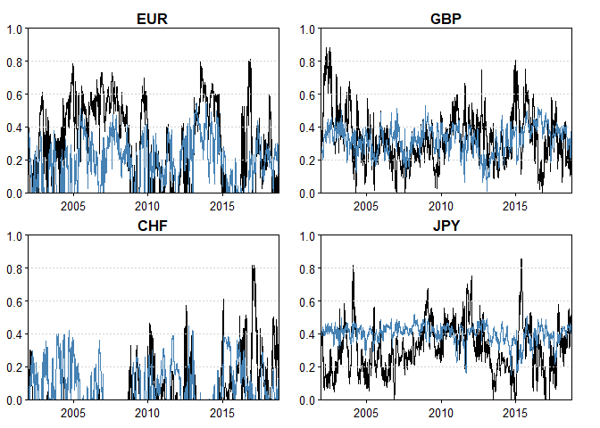

```r
par(mfrow=c(ceiling(k/2),2), oma=c(0,0,0,0)+0.5, mar=c(1,1,1,1)+0.5, mgp=c(1,0.4,0))
for (i in 1:k) {
  plot(date, mvp$portfolio_weights[,i], type="l", las=1, xaxs="i", yaxs="i", xlab="", ylab="", main=NAMES[i], tck=-0.02, ylim=c(0,1))
  grid(NA, NULL)
  lines(date, mcp$portfolio_weights[,i], col="steelblue")
  box()
}
```

Plot bivariate portfolio weights

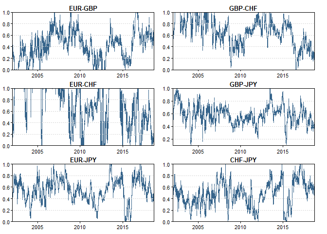

```r
kk = k*(k-1)/2
rows = ceiling(sqrt(kk))
cols = ceiling(kk/rows)

par(mfcol=c(rows, cols), oma=c(0,0,0,0)+0.5, mar=c(1,1,1,1)+0.5, mgp=c(1,0.4,0))
for (j in 1:k) {
  for (i in 1:k) {
    if (j<i) {
      plot(date, bp$portfolio_weights[i,j,], type="l", las=1, xaxs="i", yaxs="i", xlab="", ylab="", main=paste0(NAMES[j],"-",NAMES[i]), tck=-0.02, col="steelblue4")
      grid(NA, NULL)
      box()
    }
  }
}
```

Plot hedge ratios

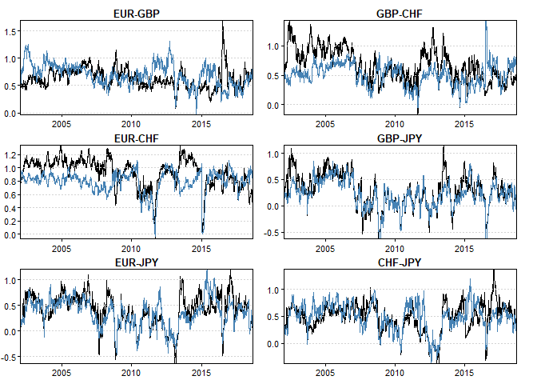

```r
par(mfcol=c(rows, cols), oma=c(0,0,0,0)+0.5, mar=c(1,1,1,1)+0.5, mgp=c(1,0.4,0))
for (j in 1:k) {
  for (i in 1:k) {
    if (j<i) {
      plot(date, hr$hedge_ratio[i,j,], type="l", las=1, xaxs="i", yaxs="i", xlab="", ylab="", main=paste0(NAMES[j],"-",NAMES[i]), tck=-0.02)
      grid(NA, NULL)
      lines(date, hr$hedge_ratio[j,i,], col="steelblue")
      box()
    }
  }
}
```

Plot cumulative bivariate portfolio returns

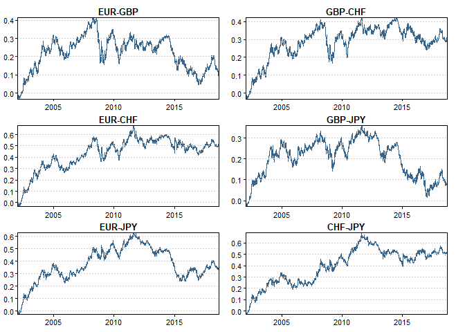

```r
par(mfcol=c(rows, cols), oma=c(0,0,0,0)+0.5, mar=c(1,1,1,1)+0.5, mgp=c(1,0.4,0))
for (j in 1:k) {
  for (i in 1:k) {
    if (j<i) {
      plot(date, bp$cumulative_portfolio_return[i,j,], type="l", las=1, xaxs="i", yaxs="i", xlab="", ylab="", main=paste0(NAMES[j],"-",NAMES[i]), tck=-0.02, col="steelblue4")
      grid(NA, NULL)
      box()
    }
  }
}
```

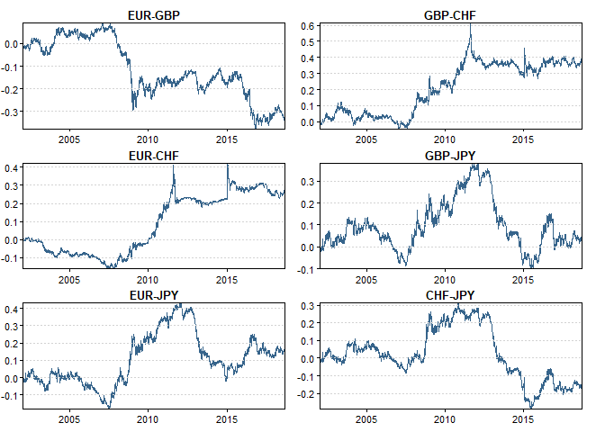

```r
par(mfcol=c(rows, cols), oma=c(0,0,0,0)+0.5, mar=c(1,1,1,1)+0.5, mgp=c(1,0.4,0))
for (j in 1:k) {
  for (i in 1:k) {
    if (j<i) {
      plot(date, hr$cumulative_portfolio_return[i,j,], type="l", las=1, xaxs="i", yaxs="i", xlab="", ylab="", main=paste0(NAMES[j],"-",NAMES[i]), tck=-0.02, col="steelblue4")
      grid(NA, NULL)
      box()
    }
  }
}
```